# Презентация по лабораторной работе №1

Основы информационной безопасности

Дворкина Е. В

Российский университет дружбы народов, Москва, Россия

22 апреля 2024

# Информация

## Докладчик

- Дворкина Ева Владимировна
- студентка группы НКАбд-01-22
- Российский университет дружбы народов
- https://vk.com/yuri.kamori

## Цель

Освоить на практике применение режима однократного гаммирования на примере кодирования различных исходных текстов одним ключом

## Задание

Два текста кодируются одним ключом (однократное гаммирование). Требуется не зная ключа и не стремясь его определить, прочитать оба текста. Необходимо разработать приложение, позволяющее шифровать и дешифровать тексты *P*<sub>1</sub> и *P*<sub>2</sub> в режиме однократного гаммирования. Приложение должно определить вид шифротекстов *C*<sub>1</sub> и *C*<sub>2</sub> обоих текстов *P*<sub>1</sub> и P2 при известном ключе; Необходимо определить и выразить аналитически способ, при котором злоумышленник может прочитать оба текста, не зная ключа и не стремясь его определить.

## Выполнение лабораторной работы

Я выполняла лабораторную работу на языке программирования Python, используя функции, реализованные в лабораторной работе №7.

## Выполнение лабораторной работы

Используя функцию для генерации ключа, генерирую ключ, затем шифрую два разных текста одним и тем же ключом

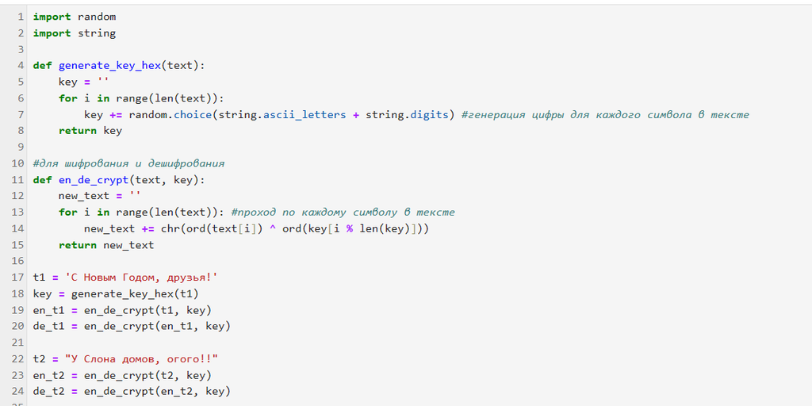

Шифрование двух текстов

Расшифровываю оба текста сначала с помощью одного ключа, затем предполагаю, что мне неизвестен ключ, но извествен один из текстов и уже расшифровываю второй, зная шифротексты и первый текст

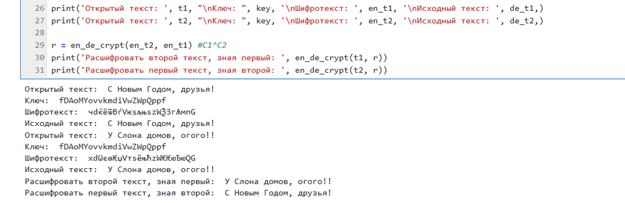

Результат работы программы

## Вывод

В ходе лабораторной работы были освоины на практике навыки применения режима однократного гаммирования на примере кодирования различных исходных текстов одним ключом.

:::